## 107-2 空間分析 期末考考題

> > Q1  
> > 請依據以下的鄰近定義，計算a.紅色網格及b.藍色網格分別的統計量，列出計算步驟及結果（列至小數後四位）。

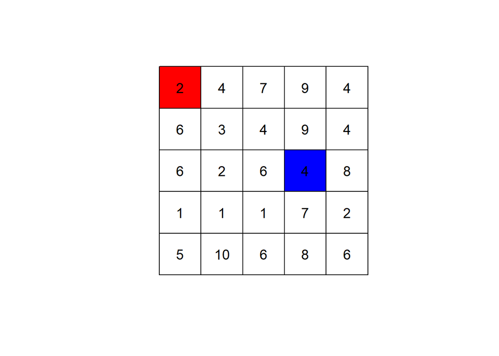

> (1)以QUEEN鄰近定義空間鄰近矩陣，**手動計算**兩個網格的Getis-Ord Local G統計量$G_i^*$。[5%]  
> (2)以ROOK鄰近並進行列標準化定義空間鄰近矩陣，**手動計算**兩個網格的Local Moran’s I統計量$I_i$。[10%]  
> (3)透過R建立網格資料，使用相同定義計算上一小題的Local Moran’s I統計量$I_i$，並驗證兩者結果是否相同。[10%]

> > Q2  
> > 圖資KH.shp為高雄市35個行政區(不含3個原住民區)，其中欄位TOWN及TOWN_ID代表行政區名稱及編號。原本資料內有2018年市長選舉的藍綠比例值數值，透過localmoran函數來檢定哪些行政區的**局部空間自相關呈現正相關(顯著水準= 0.05)**，但現有的圖資只儲存了計算後原始的Local Moran’s I統計量$I_i$和其期望值$E(I_i)$、變異數$Var(I_i)$。

> (1)計算p-value，並列出**局部空間自相關呈現正相關**(α= 0.05)的行政區名稱。[5%]  
> (2)對所有行政區透過**手動計算**方式來進行FDR校正，**由小到大依序**列出校正後**p-value前三低**的行政區名稱。[10%]  
> (3)透過**p.adjustSP函數**，考慮QUEEN的鄰近關係來校正FDR，並列出**局部空間自相關呈現正相關**(α= 0.05)的行政區名稱。[10%]  
> (4)上述(2)、(3)小題都是在進行FDR校正，請以文字說明，兩者概念與實作的差異為何？並比較那一個方法得出的結果較保守。[5%]

> > Q3  
> > 圖資dengue.shp為某年南高屏三縣市登革熱爆發的病例，其中欄位count為病例數。請以各鄉鎮病例密度（即每單位面積有多少病例）作為參考數值，以距離作為鄰近基準，來量測空間自相關。

> (1)評估各鄉鎮中心之間的距離，決定**鄰近距離d**，並說明選擇的原因。[5%]  
> (2)以上述(1)的距離，以一階鄰近(距離0~d)為定義，繪製出LISA地圖(以顯著水準=0.1，呈現出HH、LL、HL、LH)。[5%]  
> (3)以**第二階鄰近**(距離d~2d)為定義，繪製出LISA地圖(以顯著水準=0.1，呈現出HH、LL、HL、LH)。[10%]  
> (4)說明(2)、(3)地圖代表的地理意涵。[5%]

> > Q4  
> > 圖資TPE.shp為台北市次分區，其中欄位DEN代表個次分區中的人口密度。以QUEEN鄰近並進行列標準化定義鄰近關係，來計算空間自相關的數值。過去課程實習在檢定的方法，都是以moran.mc或localmoran函數中已經執行的結果，如下圖。

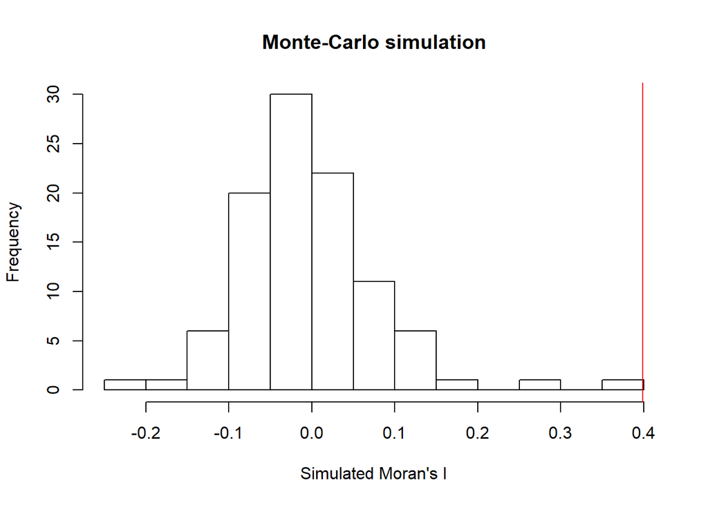

> > 希望能用手動模擬的方式，也能得到類似的結果，因此，請透過排列檢定(permutation test)，模擬99次的隨機情形，比較觀察值與隨機值。

> (1)繪製出Global Moran’s I的直方圖。[10%]  
> (2) 透過與隨機值的排序比較，計算各個區局部空間自相關呈現正相關的p-value。並以data.frame的方式，呈現**行政區名、localmoran函數算出來的p-value、模擬計算p-value**，如下圖。[10%]  
> (注意：模擬次數加上觀察值為100次，故模擬計算p-value一定是二位以下的小數；而下圖localmoran函數算出來的p-value有經過四捨五入)

> ```
> ##          TPE p_org p.sim
> ## 0   三民地區  0.60  0.62
> ## 1   東社地區  0.63  0.68
> ## 2   中崙地區  0.04  0.02
> ## 3   本鎮地區  0.04  0.04
> ## 4 三張犁地區  0.08  0.06
> ```